# Riskuppfattning av COVID-19/coronaviruset i Sverige

[Osäkerhets- och evidenslabbet](https://www.cec.lu.se/research/unevil) Lunds Universitet

29/04/2020

## Introduktion

Detta dokument jämför resultaten av en internationell undersökning utförd av [undersökningen av Winton Center for Risk and Evidence Communication](https://www.cam.ac.uk/stories/wintoncovid1) om riskuppfattning och syn på hantering av coronaviruset. Den svenska delen av undersökningen gjordes under perioden 28-29 mars 2020 och 19-24 april 2020. Vid varje omgång har 700 svar från ett representativt urval av svenska befolkningen svarat på undersökningen genom systemet Qualitrics.

Vi presenterar här resultaten från de två tillfällena på ett sätt som gör det möjligt att jämföra. Generellt sett är det ingen stor skillnad mellan svaren från april jämfört med mars. Just nu arbetar forskare med analys av detta material.

Data är offentlig för att göra det möjligt för beslutsfattare att bilda sig en uppfattning om hur vi upplever COVID-19. Vi har gjort en liknande [översikt av publika data i samma studie från flera länder](https://lu-unevil.github.io/WintonReport/WintonReport-se.html).

Kontakt: Ullrika Sahlin, Lunds Universitet

Här följer en sammanställning av vad data visar. Jämförelser i svar mellan mars och april är testade med en signifikansnivå på 0.001.

## Uppfattning av effekter av COVID-19

Var fjärde person har upplevt ekonomiska svårigheter som ett resultat av pandemin. Andelen var något färre i april jämfört med mars. Det är lika många som har upplevt sociala svårigheter som inte har gjort det. Färre än 25% har upplevt svårigheter i sin mentala hälsa som ett resultat av pandemin. Tre av fyra har inga vänner eller familj som testats positiva eller dött av viruset.

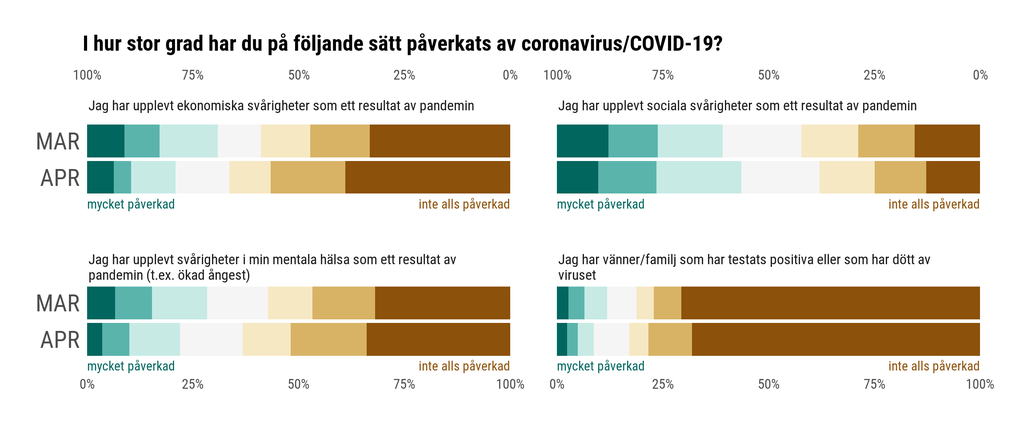

**Wilcox test**

| question | statistic | p.value | method | alternative |
| --- | --- | --- | --- | --- |
| Jag har upplevt ekonomiska svårigheter som ett resultat av pandemin | 270944.5 | 0.0002285 | Wilcoxon rank sum test with continuity correction | two.sided |
| Jag har upplevt sociala svårigheter som ett resultat av pandemin | 233733.5 | 0.1850804 | Wilcoxon rank sum test with continuity correction | two.sided |
| Jag har upplevt svårigheter i min mentala hälsa som ett resultat av pandemin (t.ex. ökad ångest) | 261261.0 | 0.0186772 | Wilcoxon rank sum test with continuity correction | two.sided |
| Jag har vänner/familj som har testats positiva eller som har dött av viruset | 240898.0 | 0.6598718 | Wilcoxon rank sum test with continuity correction | two.sided |

## Uppfattning av risker med COVID-19

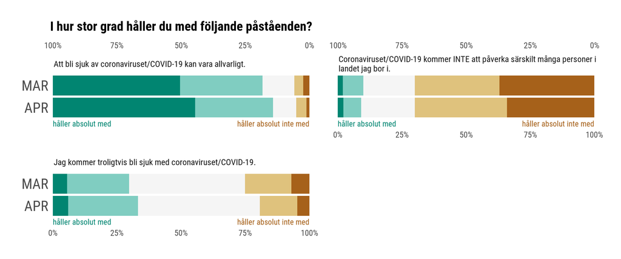

**Wilcox test**

| question | statistic | p.value | method | alternative |
| --- | --- | --- | --- | --- |
| Att bli sjuk av coronaviruset/COVID-19 kan vara allvarligt. | 226546.0 | 0.0143829 | Wilcoxon rank sum test with continuity correction | two.sided |
| Jag kommer troligtvis bli sjuk med coronaviruset/COVID-19. | 226764.5 | 0.0194151 | Wilcoxon rank sum test with continuity correction | two.sided |
| Coronaviruset/COVID-19 kommer INTE att påverka särskilt många personer i landet jag bor i. | 237896.0 | 0.5144261 | Wilcoxon rank sum test with continuity correction | two.sided |

## Oro för COVID-19

Jämfört med andra frågor, är COVID-19 det som flest är oroliga för. Näst efter COVID-19 är personer oroliga för arbetslöshet, brottslighet, klimatförändring och invandring. Oro för brottslighet har minskat i april jämfört med mars. Bland de frågor vi jämför, anser flest att det är troligt att de blir smittade med COVID-19 och att de drabbas av ekonomiska problem. I april jämfört med mars, ser vi en minskad oro för att man som individ drabbas av ekonomiska problem.

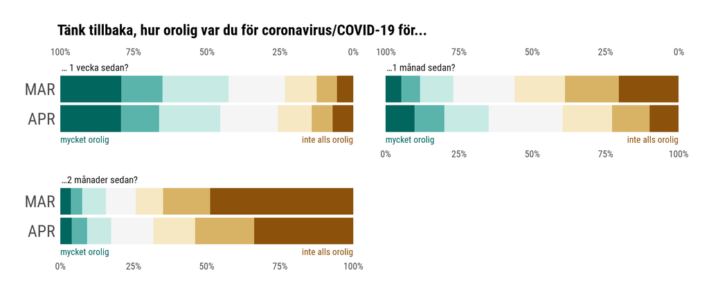

**Wilcox test**

| question | statistic | p.value | method | alternative |
| --- | --- | --- | --- | --- |
| … 1 vecka sedan? | 250174.5 | 0.3499293 | Wilcoxon rank sum test with continuity correction | two.sided |
| …1 månad sedan? | 189889.0 | 0.0000000 | Wilcoxon rank sum test with continuity correction | two.sided |
| …2 månader sedan? | 208401.5 | 0.0000014 | Wilcoxon rank sum test with continuity correction | two.sided |

## Oro för COVID-19 jämfört med andra frågor

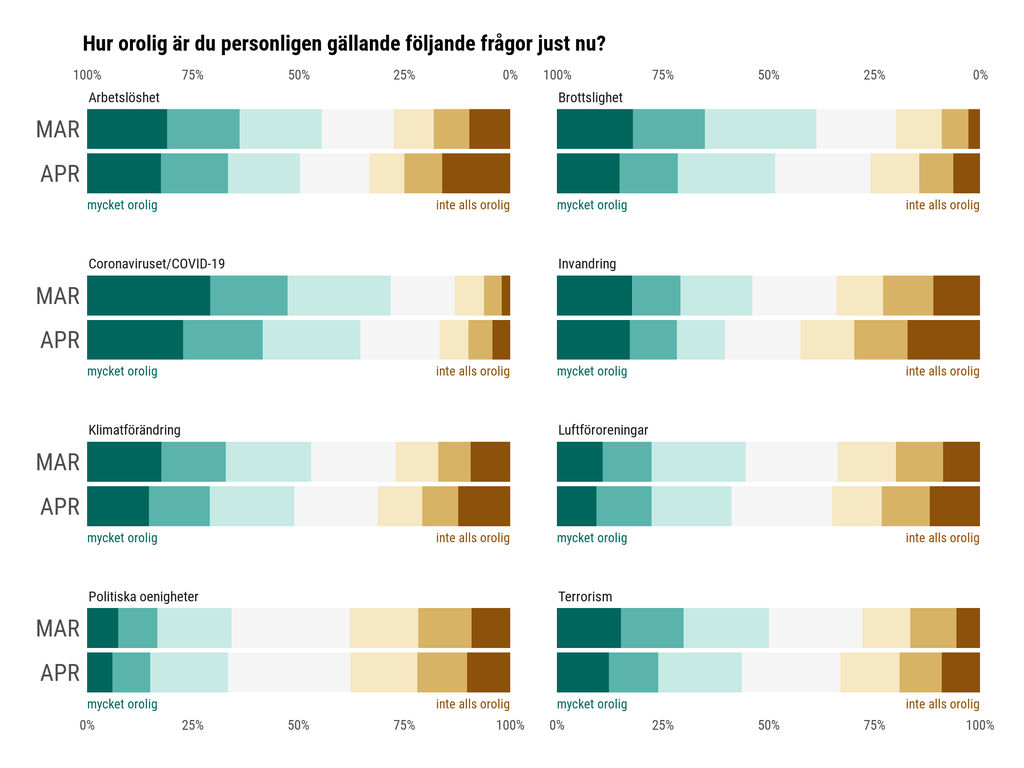

**Wilcox test**

| question | statistic | p.value | method | alternative |
| --- | --- | --- | --- | --- |
| Klimatförändring | 258383.5 | 0.0368467 | Wilcoxon rank sum test with continuity correction | two.sided |
| Coronaviruset/COVID-19 | 266358.5 | 0.0014244 | Wilcoxon rank sum test with continuity correction | two.sided |
| Politiska oenigheter | 245617.5 | 0.6775157 | Wilcoxon rank sum test with continuity correction | two.sided |
| Invandring | 263375.5 | 0.0058591 | Wilcoxon rank sum test with continuity correction | two.sided |
| Arbetslöshet | 260273.0 | 0.0168444 | Wilcoxon rank sum test with continuity correction | two.sided |
| Terrorism | 263534.5 | 0.0053577 | Wilcoxon rank sum test with continuity correction | two.sided |
| Luftföroreningar | 251521.5 | 0.2257260 | Wilcoxon rank sum test with continuity correction | two.sided |
| Brottslighet | 270121.5 | 0.0001872 | Wilcoxon rank sum test with continuity correction | two.sided |

## Riskuppfattning av COVID-19 jämfört med andra frågor - direkta och personliga effekter

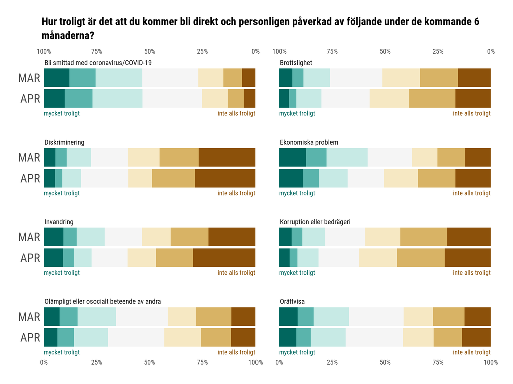

**Wilcox test**

| question | statistic | p.value | method | alternative |
| --- | --- | --- | --- | --- |
| Brottslighet | 259948.0 | 0.0184150 | Wilcoxon rank sum test with continuity correction | two.sided |
| Ekonomiska problem | 273949.0 | 0.0000232 | Wilcoxon rank sum test with continuity correction | two.sided |
| Diskriminering | 251366.0 | 0.2309089 | Wilcoxon rank sum test with continuity correction | two.sided |
| Olämpligt eller osocialt beteende av andra | 247899.0 | 0.4693697 | Wilcoxon rank sum test with continuity correction | two.sided |
| Orättvisa | 246177.0 | 0.6237062 | Wilcoxon rank sum test with continuity correction | two.sided |
| Korruption eller bedrägeri | 251123.5 | 0.2453991 | Wilcoxon rank sum test with continuity correction | two.sided |
| Invandring | 265307.0 | 0.0020580 | Wilcoxon rank sum test with continuity correction | two.sided |
| Bli smittad med coronavirus/COVID-19 | 241959.0 | 0.9357462 | Wilcoxon rank sum test with continuity correction | two.sided |

## Riskuppfattning av COVID-19 jämfört med andra frågor - direkta effekter på vänner och familj

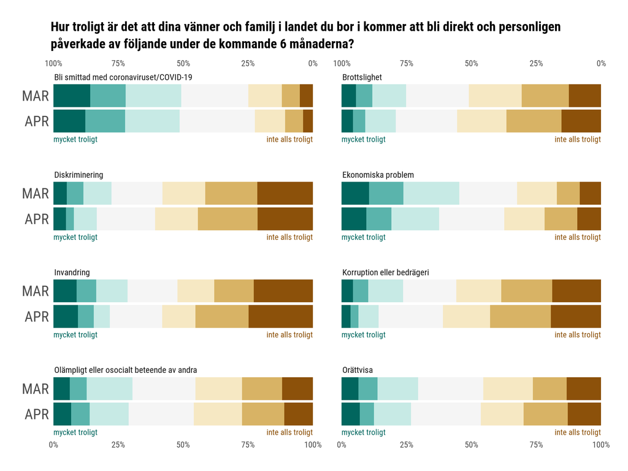

**Wilcox test**

| question | statistic | p.value | method | alternative |
| --- | --- | --- | --- | --- |
| Brottslighet | 259411.0 | 0.0171095 | Wilcoxon rank sum test with continuity correction | two.sided |
| Ekonomiska problem | 262188.0 | 0.0058659 | Wilcoxon rank sum test with continuity correction | two.sided |
| Diskriminering | 252622.5 | 0.1434195 | Wilcoxon rank sum test with continuity correction | two.sided |
| Olämpligt eller osocialt beteende av andra | 242654.0 | 0.9136333 | Wilcoxon rank sum test with continuity correction | two.sided |
| Orättvisa | 248734.5 | 0.3503526 | Wilcoxon rank sum test with continuity correction | two.sided |
| Korruption eller bedrägeri | 260681.0 | 0.0104921 | Wilcoxon rank sum test with continuity correction | two.sided |
| Invandring | 258936.0 | 0.0205204 | Wilcoxon rank sum test with continuity correction | two.sided |
| Bli smittad med coronaviruset/COVID-19 | 240701.5 | 0.8754110 | Wilcoxon rank sum test with continuity correction | two.sided |

## Syn på vaccin för COVID-19

Tre utav fyra skulle rekommendera utsatta vänner och familj att bli vaccinerade, men en något lägre andel kan tänka sig att själva vaccinera sig.

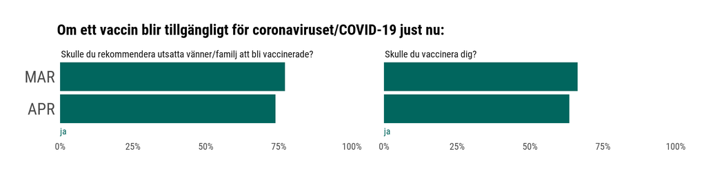

**Prop test**

| question | estimate1 | estimate2 | statistic | p.value | parameter | conf.low | conf.high | method | alternative |
| --- | --- | --- | --- | --- | --- | --- | --- | --- | --- |
| Skulle du vaccinera dig? | 0.6632504 | 0.6350575 | 1.082251 | 0.2981946 | 1 | -0.0236099 | 0.0799957 | 2-sample test for equality of proportions with continuity correction | two.sided |
| Skulle du rekommendera utsatta vänner/familj att bli vaccinerade? | 0.7715959 | 0.7385057 | 1.865054 | 0.1720426 | 1 | -0.0137154 | 0.0798957 | 2-sample test for equality of proportions with continuity correction | two.sided |

## Sökt information om COVID-19

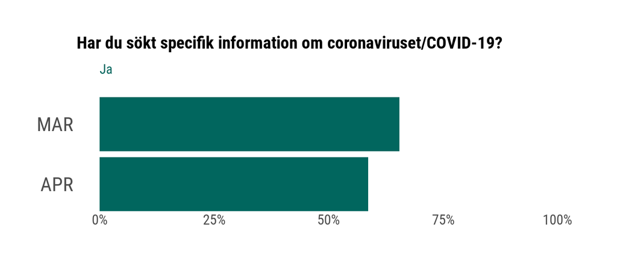

**Prop test**

| question | estimate1 | estimate2 | statistic | p.value | parameter | conf.low | conf.high | method | alternative |
| --- | --- | --- | --- | --- | --- | --- | --- | --- | --- |
|  | 0.6550725 | 0.5862069 | 6.68879 | 0.0097021 | 1 | 0.016464 | 0.1212671 | 2-sample test for equality of proportions with continuity correction | two.sided |

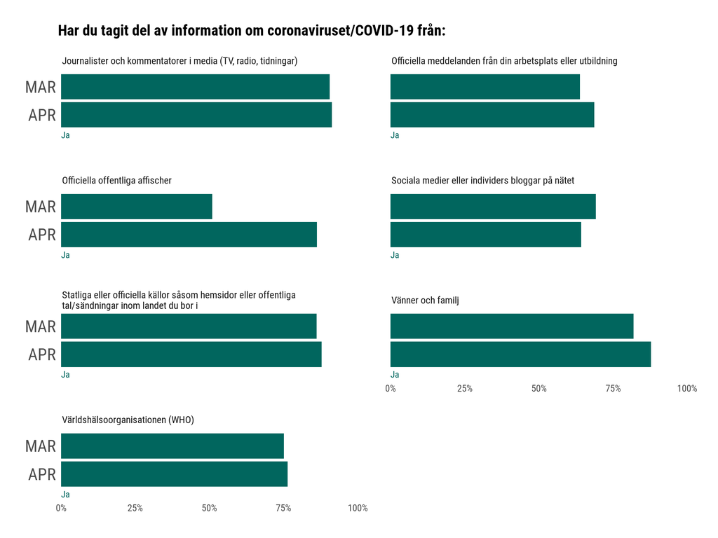

**Prop test**

| question | estimate1 | estimate2 | statistic | p.value | parameter | conf.low | conf.high | method | alternative |
| --- | --- | --- | --- | --- | --- | --- | --- | --- | --- |
| Officiella offentliga affischer | 0.5101156 | 0.8624642 | 199.0097881 | 0.0000000 | 1 | -0.3989546 | -0.3057426 | 2-sample test for equality of proportions with continuity correction | two.sided |
| Sociala medier eller individers bloggar på nätet | 0.6917511 | 0.6427547 | 3.5338519 | 0.0601279 | 1 | -0.0019516 | 0.0999444 | 2-sample test for equality of proportions with continuity correction | two.sided |
| Journalister och kommentatorer i media (TV, radio, tidningar) | 0.9060694 | 0.9124821 | 0.1041044 | 0.7469588 | 1 | -0.0380617 | 0.0252363 | 2-sample test for equality of proportions with continuity correction | two.sided |
| Statliga eller officiella källor såsom hemsidor eller offentliga tal/sändningar inom landet du bor i | 0.8612717 | 0.8783977 | 0.7561219 | 0.3845449 | 1 | -0.0539234 | 0.0196713 | 2-sample test for equality of proportions with continuity correction | two.sided |
| Officiella meddelanden från din arbetsplats eller utbildning | 0.6382055 | 0.6867816 | 3.4456676 | 0.0634178 | 1 | -0.0997264 | 0.0025741 | 2-sample test for equality of proportions with continuity correction | two.sided |
| Vänner och familj | 0.8193642 | 0.8780488 | 8.8670430 | 0.0029037 | 1 | -0.0976982 | -0.0196711 | 2-sample test for equality of proportions with continuity correction | two.sided |
| Världshälsoorganisationen (WHO) | 0.7514451 | 0.7632712 | 0.2038480 | 0.6516326 | 1 | -0.0583513 | 0.0346991 | 2-sample test for equality of proportions with continuity correction | two.sided |

## Tilltro till information om COVID-19

Information om COVID-19 från WHO och officiella källor har högst förtroende, medan sociala medier och journalister har lägst förtroende. Tilltro till information om COVID-19 från journalister och media har till och med minskat i april jämfört med mars.

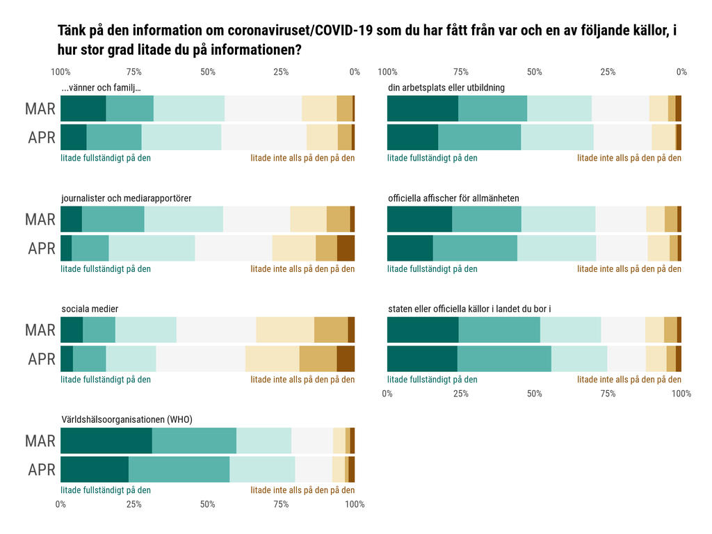

**Wilcox test**

| question | statistic | p.value | method | alternative |
| --- | --- | --- | --- | --- |
| …vänner och familj… | 177681.5 | 0.2690363 | Wilcoxon rank sum test with continuity correction | two.sided |
| staten eller officiella källor i landet du bor i | 176500.0 | 0.4569710 | Wilcoxon rank sum test with continuity correction | two.sided |
| journalister och mediarapportörer | 226514.0 | 0.0000030 | Wilcoxon rank sum test with continuity correction | two.sided |
| officiella affischer för allmänheten | 108110.5 | 0.3905294 | Wilcoxon rank sum test with continuity correction | two.sided |
| sociala medier | 114962.5 | 0.0189217 | Wilcoxon rank sum test with continuity correction | two.sided |
| Världshälsoorganisationen (WHO) | 145187.0 | 0.1066474 | Wilcoxon rank sum test with continuity correction | two.sided |
| din arbetsplats eller utbildning | 107441.5 | 0.3512395 | Wilcoxon rank sum test with continuity correction | two.sided |

## Syn på vetenskaplig kunskap om COVID-19

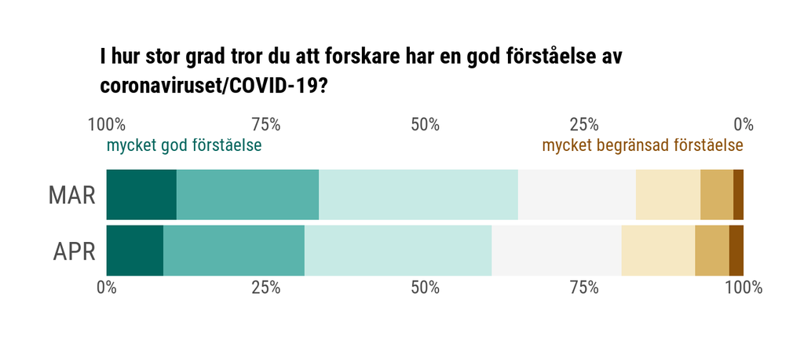

**Wilcox test**

| question | statistic | p.value | method | alternative |
| --- | --- | --- | --- | --- |
|  | 248363 | 0.1139329 | Wilcoxon rank sum test with continuity correction | two.sided |

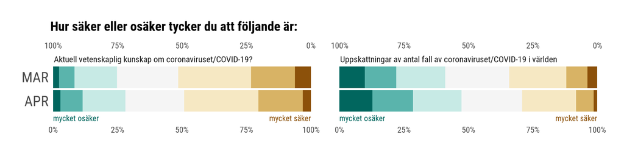

**Wilcox test**

| question | statistic | p.value | method | alternative |
| --- | --- | --- | --- | --- |
| Aktuell vetenskaplig kunskap om coronaviruset/COVID-19? | 225517.5 | 0.0838182 | Wilcoxon rank sum test with continuity correction | two.sided |
| Uppskattningar av antal fall av coronaviruset/COVID-19 i världen | 215642.5 | 0.0024098 | Wilcoxon rank sum test with continuity correction | two.sided |

## Syn på nationella åtgärder

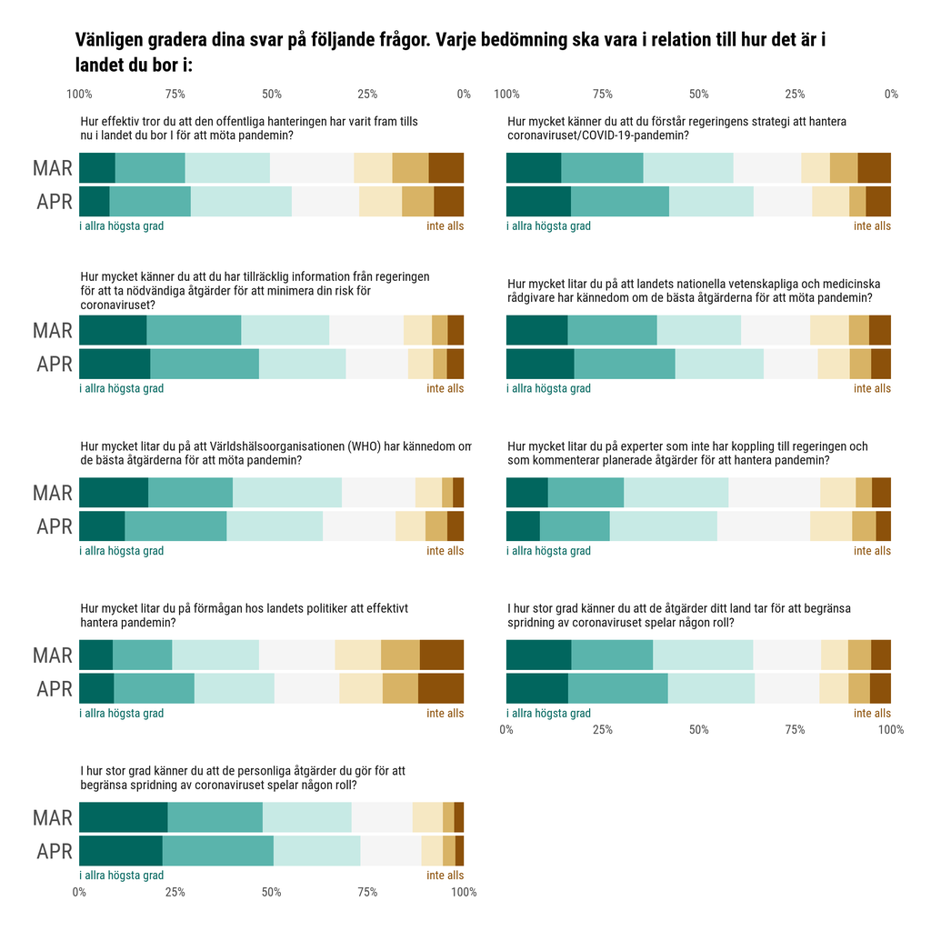

**Wilcox test**

| question | statistic | p.value | method | alternative |
| --- | --- | --- | --- | --- |
| Hur mycket känner du att du förstår regeringens strategi att hantera coronaviruset/COVID-19-pandemin? | 220682.0 | 0.0103837 | Wilcoxon rank sum test with continuity correction | two.sided |
| Hur mycket litar du på förmågan hos landets politiker att effektivt hantera pandemin? | 228497.5 | 0.1625469 | Wilcoxon rank sum test with continuity correction | two.sided |
| Hur mycket litar du på att landets nationella vetenskapliga och medicinska rådgivare har kännedom om de bästa åtgärderna för att möta pandemin? | 224930.5 | 0.0583452 | Wilcoxon rank sum test with continuity correction | two.sided |
| Hur mycket litar du på experter som inte har koppling till regeringen och som kommenterar planerade åtgärder för att hantera pandemin? | 250419.0 | 0.1177129 | Wilcoxon rank sum test with continuity correction | two.sided |
| Hur mycket litar du på att Världshälsoorganisationen (WHO) har kännedom om de bästa åtgärderna för att möta pandemin? | 256770.5 | 0.0147141 | Wilcoxon rank sum test with continuity correction | two.sided |
| Hur effektiv tror du att den offentliga hanteringen har varit fram tills nu i landet du bor I för att möta pandemin? | 229546.0 | 0.2092201 | Wilcoxon rank sum test with continuity correction | two.sided |
| I hur stor grad känner du att de personliga åtgärder du gör för att begränsa spridning av coronaviruset spelar någon roll? | 233691.0 | 0.4884839 | Wilcoxon rank sum test with continuity correction | two.sided |
| I hur stor grad känner du att de åtgärder ditt land tar för att begränsa spridning av coronaviruset spelar någon roll? | 234504.5 | 0.5951690 | Wilcoxon rank sum test with continuity correction | two.sided |
| Hur mycket känner du att du har tillräcklig information från regeringen för att ta nödvändiga åtgärder för att minimera din risk för coronaviruset? | 227651.5 | 0.1165380 | Wilcoxon rank sum test with continuity correction | two.sided |

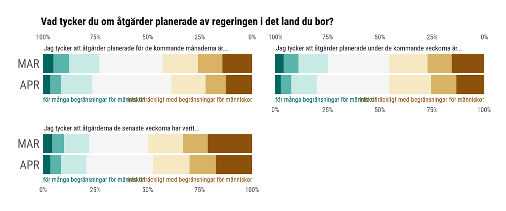

**Wilcox test**

| question | statistic | p.value | method | alternative |
| --- | --- | --- | --- | --- |
| Jag tycker att åtgärderna de senaste veckorna har varit… | 227018.5 | 0.4366588 | Wilcoxon rank sum test with continuity correction | two.sided |
| Jag tycker att åtgärder planerade under de kommande veckorna är… | 213323.5 | 0.5073993 | Wilcoxon rank sum test with continuity correction | two.sided |
| Jag tycker att åtgärder planerade för de kommande månaderna är… | 185788.0 | 0.8085587 | Wilcoxon rank sum test with continuity correction | two.sided |

## Förtroende för individer och samhället

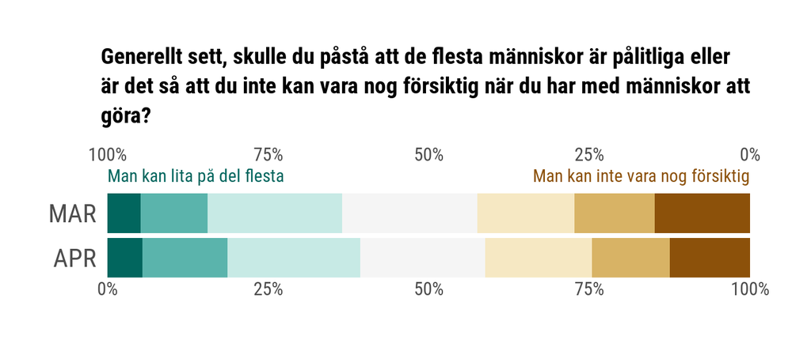

**Wilcox test**

| question | statistic | p.value | method | alternative |
| --- | --- | --- | --- | --- |
|  | 233798.5 | 0.1869414 | Wilcoxon rank sum test with continuity correction | two.sided |

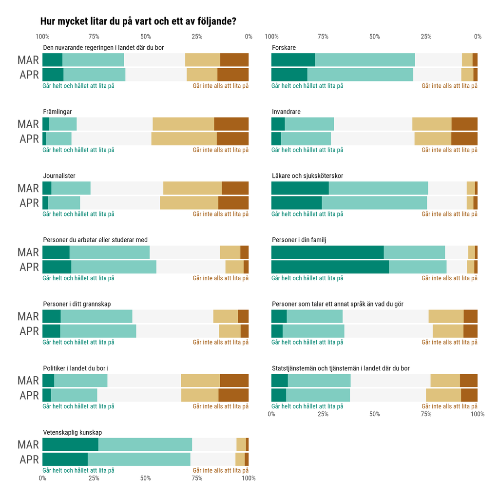

**Wilcox test**

| question | statistic | p.value | method | alternative |
| --- | --- | --- | --- | --- |
| Personer i din familj | 238328.0 | 0.4048105 | Wilcoxon rank sum test with continuity correction | two.sided |
| Journalister | 256028.5 | 0.1049800 | Wilcoxon rank sum test with continuity correction | two.sided |
| Den nuvarande regeringen i landet där du bor | 243627.0 | 0.8889176 | Wilcoxon rank sum test with continuity correction | two.sided |
| Vetenskaplig kunskap | 255320.5 | 0.1168194 | Wilcoxon rank sum test with continuity correction | two.sided |
| Statstjänstemän och tjänstemän i landet där du bor | 248186.5 | 0.5898598 | Wilcoxon rank sum test with continuity correction | two.sided |
| Personer i ditt grannskap | 237365.5 | 0.3065865 | Wilcoxon rank sum test with continuity correction | two.sided |
| Personer du arbetar eller studerar med | 233184.0 | 0.1434872 | Wilcoxon rank sum test with continuity correction | two.sided |
| Personer som talar ett annat språk än vad du gör | 242307.0 | 0.7433146 | Wilcoxon rank sum test with continuity correction | two.sided |
| Främlingar | 247540.5 | 0.6527757 | Wilcoxon rank sum test with continuity correction | two.sided |
| Invandrare | 246202.0 | 0.7552663 | Wilcoxon rank sum test with continuity correction | two.sided |
| Läkare och sjuksköterskor | 251815.0 | 0.3046026 | Wilcoxon rank sum test with continuity correction | two.sided |
| Forskare | 252377.5 | 0.2690297 | Wilcoxon rank sum test with continuity correction | two.sided |
| Politiker i landet du bor i | 253793.5 | 0.2072535 | Wilcoxon rank sum test with continuity correction | two.sided |

## Syn på individ och samhälle

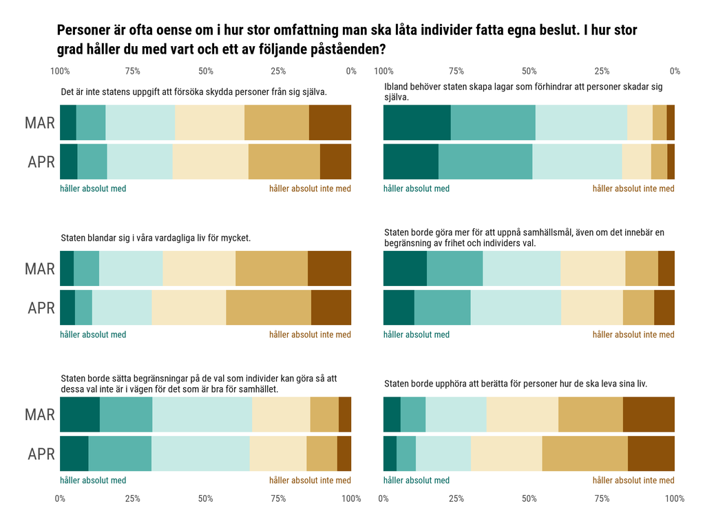

**Wilcox test**

| question | statistic | p.value | method | alternative |
| --- | --- | --- | --- | --- |
| Staten blandar sig i våra vardagliga liv för mycket. | 252027.5 | 0.2317870 | Wilcoxon rank sum test with continuity correction | two.sided |
| Ibland behöver staten skapa lagar som förhindrar att personer skadar sig själva. | 251976.5 | 0.2294236 | Wilcoxon rank sum test with continuity correction | two.sided |
| Det är inte statens uppgift att försöka skydda personer från sig själva. | 239030.5 | 0.5347709 | Wilcoxon rank sum test with continuity correction | two.sided |
| Staten borde upphöra att berätta för personer hur de ska leva sina liv. | 255726.5 | 0.0650423 | Wilcoxon rank sum test with continuity correction | two.sided |
| Staten borde göra mer för att uppnå samhällsmål, även om det innebär en begränsning av frihet och individers val. | 252703.0 | 0.2162208 | Wilcoxon rank sum test with continuity correction | two.sided |
| Staten borde sätta begränsningar på de val som individer kan göra så att dessa val inte är i vägen för det som är bra för samhället. | 248855.0 | 0.4430643 | Wilcoxon rank sum test with continuity correction | two.sided |

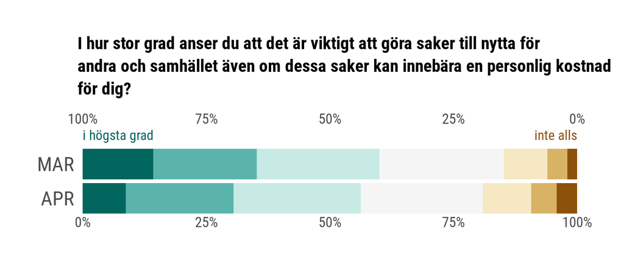

**Wilcox test**

| question | statistic | p.value | method | alternative |
| --- | --- | --- | --- | --- |
|  | 262316 | 0.0082461 | Wilcoxon rank sum test with continuity correction | two.sided |

## Erfarenheter av COVID-19 eller liknande sjukdomar

Färre än 10% av de som svarade var eller hade varit smittad med COVID-19.

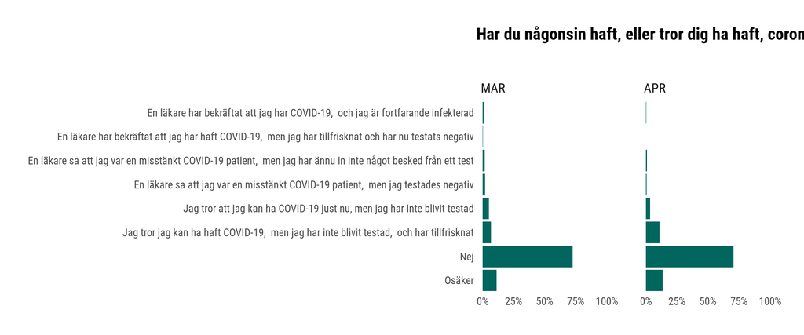

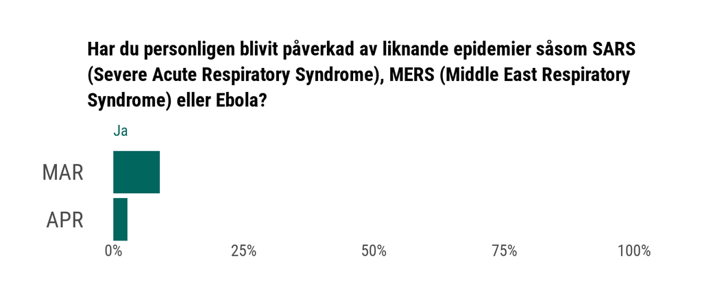

**Prop test**

| question | estimate1 | estimate2 | statistic | p.value | parameter | conf.low | conf.high | method | alternative |
| --- | --- | --- | --- | --- | --- | --- | --- | --- | --- |
|  | 0.0886981 | 0.0271817 | 23.11719 | 1.5e-06 | 1 | 0.0358054 | 0.0872275 | 2-sample test for equality of proportions with continuity correction | two.sided |

## Riskuppfattningsindex

Som visas i (Dryhurst et al. 2020) kan riskuppfattning sammanföras till ett index, som kombinerar svar på följande frågor

| Fråga | Val |
| --- | --- |
| *I hur stor grad håller du med följande påståenden?* Att bli sjuk av coronaviruset/COVID-19 kan vara allvarligt. | håller absolut inte med(1)..håller absolut med(5) |
| *I hur stor grad håller du med följande påståenden?* Jag kommer troligtvis bli sjuk med coronaviruset/COVID-19. | håller absolut inte med(1)..håller absolut med(5) |
| *I hur stor grad håller du med följande påståenden?* Coronaviruset/COVID-19 kommer INTE att påverka särskilt många personer i landet jag bor i. | håller absolut inte med(1)..håller absolut med(5) |
| *Hur orolig är du personligen gällande följande frågor just nu?* Coronaviruset/COVID-19 | inte alls orolig(1)..mycket orolig(7) |
| *Hur troligt är det att dina vänner och familj i landet du bor i kommer att bli direkt och personligen påverkade av följande under de kommande 6 månaderna?* Bli smittad med coronaviruset/COVID-19 | inte alls troligt(1)..mycket troligt(7) |
| *Hur troligt är det att du kommer bli direkt och personligen påverkad av följande under de kommande 6 månaderna?* Bli smittad med coronavirus/COVID-19 | inte alls troligt(1)..mycket troligt(7) |

Index för riskuppfattning är ett medelvärde av frågorna i tabellen. Frågor vars svar ges på skalan 1..5 har omräknats $nyttvärde = gammaltvärde * 1,5 - 0,5$. För frågan som anges med negation (dvs “kommer INTE att påverka”) har svaren inverteras.

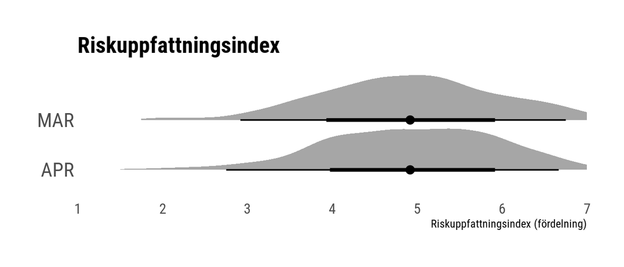

## Referenser

Dryhurst, Sarah, Claudia R. Schneider, John Kerr, Alexandra L. J. Freeman, Gabriel Recchia, Anne Marthe van der Bles, David Spiegelhalter, and Sander van der Linden. 2020. “Risk Perceptions of Covid-19 Around the World.” *Journal of Risk Research* 0 (0): 1–13. https://doi.org/10.1080/13669877.2020.1758193.